# Pipeline Performance Figure Generation

This R script creates all of the figures used to compare the performance across pipelines.

This Rmarkdown file assesses the output of CheckV, DeepVirFinder, Kaiju, VIBRANT, VirSorter, and VirSorter2 on multiple training sets of microbial DNA, primarily from NCBI. Created from fungal, viral, bacterial, archeael, protist, and plasmid DNA sequences

Please reach out to James Riddell (riddell.26@buckeyemail.osu.edu) or Bridget Hegarty (beh53@case.edu) regarding any issues, or open an issue on github.

```r
library(ggplot2)
library(plyr)
library(reshape2)
library(viridis)
library(tidyr)
library(dplyr)
library(readr)
library(data.table)
library(pROC)
library("stringr")
```

Import the file that combines the results from each of the tools from running “combining_tool_output.Rmd”:

```r
viruses <- read_tsv("../IntermediaryFiles/viral_tools_combined.tsv")
```

```r
viruses$kaiju_match_ratio <- viruses$len/viruses$checkv_length
```

Function that allows for the comparing pieces of the pipeline

```r
getting_viral_set_2 <- function(input_seqs,
                                include_vibrant=FALSE,
                                include_virsorter2=FALSE,
                                include_deepvirfinder=FALSE,
                                include_tuning_viral=FALSE,
                                tv_1=T, tv_2=T, tv_3=T, tv_4=T,
                                include_tuning_not_viral=FALSE,
                                ntv_1=T, ntv_2=T, ntv_3=T, ntv_4=T, ntv_5=F,
                                include_virsorter=FALSE) {

  keep_score <- rep(0, nrow(input_seqs))

  if (include_vibrant) {
    keep_score[input_seqs$vibrant_quality=="high quality draft"] <- keep_score[input_seqs$vibrant_quality=="high quality draft"] + 1
    keep_score[input_seqs$vibrant_quality=="medium quality draft"] <- keep_score[input_seqs$vibrant_quality=="medium quality draft"] + 1
    #keep_score[input_seqs$vibrant_quality=="low quality draft" & input_seqs$provirus] <- keep_score[input_seqs$vibrant_quality=="low quality draft" & input_seqs$provirus] + 0.5
  }

  if (include_virsorter2) {
   # keep_score[input_seqs$max_score>=0.50] <- keep_score[input_seqs$max_score>=0.50] + 0.5
    keep_score[input_seqs$max_score>=0.95] <- keep_score[input_seqs$max_score>=0.95] + 1
  }

  if (include_virsorter) {
    keep_score[input_seqs$category==1] <- keep_score[input_seqs$category==1] + 1
    #keep_score[input_seqs$category==2] <- keep_score[input_seqs$category==2] + 0.5
    #keep_score[input_seqs$category==3] <- keep_score[input_seqs$category==3] + 0.5
    keep_score[input_seqs$category==4] <- keep_score[input_seqs$category==4] + 1
    #keep_score[input_seqs$category==5] <- keep_score[input_seqs$category==5] + 0.5
    #keep_score[input_seqs$category==6] <- keep_score[input_seqs$category==6] + 0.5
  }

  if (include_deepvirfinder) {
     # add if DVF calls viral
    keep_score[(input_seqs$score>=0.9 & input_seqs$pvalue<=0.05) & input_seqs$checkv_length<20000] <- keep_score[(input_seqs$score>=0.9 & input_seqs$pvalue<=0.05) & input_seqs$checkv_length<20000] + 1
   # keep_score[(input_seqs$score>=0.7 & input_seqs$pvalue<=0.05) & input_seqs$checkv_length<20000] <- keep_score[(input_seqs$score>=0.7 & input_seqs$pvalue<=0.05) & input_seqs$checkv_length<20000] + 0.5
  }

  if (include_tuning_viral) {
    keep_score <- tuning_viral(current_score=keep_score,
                               ins=input_seqs,
                         include_tv_1=tv_1,
                         include_tv_2=tv_2,
                         include_tv_3=tv_3,
                         include_tv_4=tv_4)
  }

  if (include_tuning_not_viral) {
    # tuning removal
    keep_score <- tuning_not_viral(current_score=keep_score,
                               ins=input_seqs,
                         include_tv_1=ntv_1,
                         include_tv_2=ntv_2,
                         include_tv_3=ntv_3,
                         include_tv_4=ntv_4,
                         include_tv_5=ntv_5)

  }

  return(keep_score)

}

tuning_viral <- function(current_score, ins,
                         include_tv_1=T,
                         include_tv_2=T,
                         include_tv_3=T,
                         include_tv_4=T) {
    # tuning addition
  if (include_tv_1) {
    current_score[ins$hallmark>2] <- current_score[ins$hallmark>2] + 1
  }
  if (include_tv_2) {
    current_score[ins$Kaiju_Viral=="Viruses" & ins$kaiju_match_ratio>=0.3] <- current_score[ins$Kaiju_Viral=="Viruses" & ins$kaiju_match_ratio>=0.3] + 1
  }
    #note: had tried pulling out this rule, but better recall without sacrificing precision with it in
    #note: having kaiju removal rule didn't help
  if (include_tv_3) {
    current_score[ins$percent_unknown>=75 & ins$checkv_length<50000] <- current_score[ins$percent_unknown>=75 & ins$checkv_length<50000] + 0.5
  }
  if (include_tv_4) {
    current_score[ins$viral>=50 | ins$percent_viral>=50] <- current_score[ins$viral>=50 | ins$percent_viral>=50] + 0.5
  }
  return(current_score)
}

tuning_not_viral <- function(current_score, ins,
                         include_tv_1=T,
                         include_tv_2=T,
                         include_tv_3=T,
                         include_tv_4=T,
                         include_tv_5=F) {
    # tuning removal
  if (include_tv_2) {
    current_score[ins$checkv_viral_genes==0 & ins$checkv_host_genes>=1] <- current_score[ins$checkv_viral_genes==0 & ins$checkv_host_genes>=1] - 1
  }
  if (include_tv_3) {
    current_score[((ins$checkv_viral_genes*3) <= ins$checkv_host_genes) & !ins$provirus] <- current_score[((ins$checkv_viral_genes*3) <= ins$checkv_host_genes) & !ins$provirus] - 1
  }

  if (include_tv_5) {
    # remove if DVF calls it not viral
    current_score[ins$score<=0.7 & ins$pvalue<=0.05] <- current_score[ins$score<=0.7 & ins$pvalue<=0.05] - 1
  }

  if (include_tv_1) {
    current_score[(ins$checkv_host_genes>50) & !ins$provirus] <- -3
  }

  if (include_tv_4) {
    current_score[ins$checkv_length>500000 & ins$hallmark<=1] <- -3
  }

  return(current_score)
}
```

# Assessing performance against the “truth”

note that this is only as accurate as the annotations of the input sequences

this function calculates the precision, recall, and F1 score for each pipeline

```r
assess_performance <- function(seqtype, keep_score) {

  truepositive <- rep("not viral", length(seqtype))
  truepositive[seqtype=="virus"] <- "viral"

  #make confusion matrix
  confusion_matrix <- rep("true negative", length(keep_score))
  confusion_matrix[truepositive=="viral" & keep_score<=1] <- "false negative"
  confusion_matrix[truepositive=="viral" & keep_score>=1] <- "true positive"
  confusion_matrix[truepositive=="not viral" & keep_score>=1] <- "false positive"

  TP <- table(confusion_matrix)[4]
  FP <- table(confusion_matrix)[2]
  TN <- table(confusion_matrix)[3]
  FN <- table(confusion_matrix)[1]

  precision <- TP/(TP+FP)
  recall <- TP/(TP+FN)
  F1 <- 2*precision*recall/(precision+recall)

  MCC <- (TP*TN-FP*FN)/sqrt(as.numeric(TP+FP)*as.numeric(TP+FN)*as.numeric(TN+FP)*as.numeric(TN+FN))

  prop_viral <- (TP+FP)/(TP+FP+TN+FN)

  performance <- c(precision, recall, F1, MCC, prop_viral)
  names(performance) <- c("precision", "recall", "F1", "MCC", "prop_viral")

  return(performance)
}
```

combination of tools list

```r
combos_list <- data.frame(toolcombo=rep(0, 64),
                          tune_not_viral=rep(0, 64),
                          DVF=rep(0, 64),
                          tune_viral=rep(0, 64),
                          VIBRANT=rep(0, 64),
                          VS=rep(0, 64),
                          VS2=rep(0, 64))
p <- 1

for (i in c(0,1)){
  for (j in c(0,1)){
    for (k in c(0,1)){
      for (l in c(0,1)){
        for (m in c(0,1)){
          for (n in c(0,1)){
            combos_list$toolcombo[p] <- paste(i,j,k,l,m,n)
            combos_list$toolcombo2[p] <- paste(if(i){"tv"}else{"0"},if(j){"DVF"}else{"0"},
                                               if(k){"tnv"}else{"0"},if(l){"VB"}else{"0"},
                                               if(m){"VS"}else{"0"},if(n){"VS2"}else{"0"})
            combos_list$tune_not_viral[p] <- k
            combos_list$DVF[p] <- j
            combos_list$tune_viral[p] <- i
            combos_list$VIBRANT[p] <- l
            combos_list$VS[p] <- m
            combos_list$VS2[p] <- n
            p <- p+1
          }
        }
      }
    }
  }
}

combos_list <- combos_list[-1,]
```

this function builds a list of all of the combinations that the user wants to test. In this case, we’re comparing the performance of all unique combinations of the six tools.

```r
build_score_list <- function(input_seqs, combos) {
  output <- data.frame(precision=rep(0, nrow(combos)),
                       recall=rep(0, nrow(combos)),
                       F1=rep(0, nrow(combos)),
                       MCC=rep(0, nrow(combos)),
                       prop_viral=rep(0, nrow(combos)))
  for (i in 1:nrow(combos)) {
    keep_score <- getting_viral_set_2(input_seqs, include_vibrant = combos$VIBRANT[i],
                                            include_virsorter = combos$VS[i],
                                            include_virsorter2 = combos$VS2[i],
                                            include_tuning_viral = combos$tune_viral[i],
                                            include_tuning_not_viral = combos$tune_not_viral[i],
                                            include_deepvirfinder = combos$DVF[i])


    output[i,1:5] <- assess_performance(input_seqs$seqtype, keep_score)

    output$toolcombo[i] <- paste(combos$tune_viral[i],combos$DVF[i],
                                 combos$tune_not_viral[i], combos$VIBRANT[i],
                                 combos$VS[i], combos$VS2[i])
  }

  output[is.na(output)] <- 0

  return (output)
}
```

## Calculate the performance of each pipeline

quantifying variability between rule sets

```r
accuracy_scores <- data.frame(testing_set_index=rep(0, nrow(combos_list)*5),
                      precision=rep(0, nrow(combos_list)*5),
                       recall=rep(0, nrow(combos_list)*5),
                       F1=rep(0, nrow(combos_list)*5),
                       MCC=rep(0, nrow(combos_list)*5),
                      prop_viral=rep(0, nrow(combos_list)*5))

accuracy_scores <- cbind(testing_set_index=rep(1, nrow(combos_list)),
                              build_score_list(viruses[viruses$Index==1,], combos_list))
for (i in 2:5) {
  accuracy_scores <- rbind(accuracy_scores,
                           cbind(testing_set_index=rep(i, nrow(combos_list)),
                              build_score_list(viruses[viruses$Index==i,], combos_list)))
}
```

```r
pal <- ggthemes::tableau_color_pal(palette="Tableau 10", type="regular")
```

## Calculate the performance of each pipeline

```r
accuracy_scores$numrules <- str_count(accuracy_scores$toolcombo, "1")
#accuracy_scores <- accuracy_scores[order(accuracy_scores$numrules, decreasing=F),]
accuracy_scores <- accuracy_scores[order(accuracy_scores$MCC, decreasing=F),]
accuracy_scores$toolcombo <- factor(accuracy_scores$toolcombo, levels = unique(accuracy_scores$toolcombo))
```

accounting for rules that have multiple tools in them

```r
accuracy_scores$numtools <- accuracy_scores$numrules

for (i in 1:nrow(accuracy_scores)) {
  toolcombo <- as.character(accuracy_scores$toolcombo[i])
  if (substr(toolcombo, 1, 1)=="1") {
    accuracy_scores$numtools[i] <- accuracy_scores$numtools[i] + 3
  }

  if (substr(toolcombo, 5, 5)=="1") {
    accuracy_scores$numtools[i] <- accuracy_scores$numtools[i] + 4
  }
}

accuracy_scores$numtools[accuracy_scores$numtools>6] <- 6
```

```r
accuracy_scores$numrules <- as.factor(accuracy_scores$numrules)
accuracy_scores$numtools <- as.factor(accuracy_scores$numtools)
```

```r
accuracy_scores$ruletype <- "other"
accuracy_scores$ruletype[accuracy_scores$toolcombo %in% c("0 0 1 0 0 1",
                                                          "0 0 1 1 0 0",
                                                          "0 0 0 1 0 0")] <- "high precision"
accuracy_scores$ruletype[accuracy_scores$toolcombo %in% c("1 1 0 0 1 1",
                                                          "1 1 0 1 1 1",
                                                          "1 1 0 0 0 1",
                                                          "1 1 0 1 0 1")] <- "high recall"
accuracy_scores$ruletype[accuracy_scores$toolcombo %in% c("0 0 1 0 0 1",
                                                          "0 1 1 0 0 1",
                                                          "0 0 0 0 0 1",
                                                          "1 0 1 1 0 1",
                                                          "1 0 1 0 1 1",
                                                          "1 0 1 0 0 1")] <- "high MCC"
#accuracy_scores$ruletype[accuracy_scores$toolcombo %in% c("0 0 1 0 0 1")] <- "high MCC and high precision"
accuracy_scores$ruletype[accuracy_scores$toolcombo %in% c("1 1 1 1 1 1")] <- "all"
```

```r
accuracy_scores_melt <- accuracy_scores %>%
  select(testing_set_index, precision, recall, MCC, prop_viral, numrules, numtools, toolcombo, ruletype) %>%
  pivot_longer(cols=c(precision, recall, MCC, prop_viral),
               names_to="performance_metric",
               values_to="performance_metric_score")
```

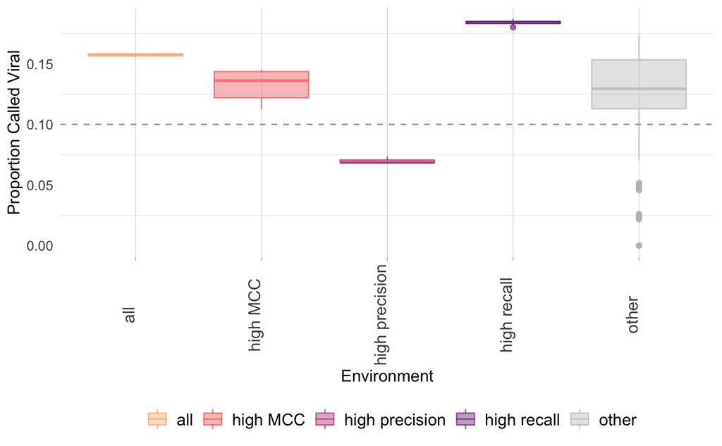

```r
fig <- ggplot(accuracy_scores_melt[accuracy_scores_melt$performance_metric=="prop_viral",],
              aes(x=ruletype, y=performance_metric_score,
                                  color=ruletype, fill=ruletype)) +
  geom_boxplot() +
  #geom_point() +
  theme_light() +
  theme(
    panel.grid.major.y = element_blank(),
    panel.border = element_blank(),
    axis.ticks.y = element_blank(),
    legend.position = "bottom",
    axis.text.y=element_text(size=10),
    axis.text.x=element_text(size=12, angle = 90, vjust = -0.1),
    legend.text=element_text(size=12),
    axis.title=element_text(size=12),
    strip.background = element_rect(fill="white", color="grey"),
    strip.text = element_text(color="black", size=12)
  ) +
  xlab("Environment") +
  ylab("Proportion Called Viral") +
  scale_fill_manual(name="",
                     values = alpha(c(rev(magma(7)[3:6]), "grey"), 0.4)) +
  scale_color_manual(name="",
                     values = alpha(c(rev(magma(7)[3:6]), "grey"), 0.6)) +
  geom_hline(yintercept = 0.1, linetype="dashed", color="dark grey")

fig
```